# Actividads practicas dia 3

Ana Letycia

06/12/2021

## Datos

Puedes bajar el conjunto de datos [aqui](https://www.kaggle.com/jamesvandenberg/renewable-power-generation/download)

Importa la tabla de datos utilizando la funcion read.csv()

```r
energy = read.csv("../tabelas/energy/Continent_Consumption_TWH.csv")
```

```r
str(energy)
```

```
## 'data.frame':    31 obs. of  12 variables:
##  $ Year         : int  1990 1991 1992 1993 1994 1995 1996 1997 1998 1999 ...
##  $ World        : num  101856 102484 102588 103647 104449 ...
##  $ OECD         : num  52602 53207 53789 54614 55580 ...
##  $ BRICS        : num  26621 26435 25993 26284 25993 ...
##  $ Europe       : num  20655 20632 20190 20190 20085 ...
##  $ North.America: num  24667 24842 25342 25830 26365 ...
##  $ Latin.America: num  5373 5501 5629 5675 5989 ...
##  $ Asia         : num  24574 24784 25691 26877 28098 ...
##  $ Pacific      : num  1198 1186 1210 1268 1279 ...
##  $ Africa       : num  4408 4536 4582 4722 4803 ...
##  $ Middle.East  : num  2582 2745 3082 3349 3640 ...
##  $ CIS          : num  16049 15898 14340 13247 11607 ...
```

```r
energy = energy[, c(1:2, 5:10)]
```

```r
head(energy)
```

```
##   Year    World   Europe North.America Latin.America     Asia Pacific  Africa
## 1 1990 101855.5 20654.88      24667.23       5373.06 24574.19 1197.89 4407.77
## 2 1991 102483.6 20631.62      24841.68       5500.99 24783.53 1186.26 4535.70
## 3 1992 102588.2 20189.68      25341.77       5628.92 25690.67 1209.52 4582.22
## 4 1993 103646.6 20189.68      25830.23       5675.44 26876.93 1267.67 4721.78
## 5 1994 104449.0 20085.01      26365.21       5989.45 28098.08 1279.30 4803.19
## 6 1995 107112.3 20713.03      26714.11       6024.34 29761.17 1290.93 5000.90
```

```r
energy_latam = energy[,c(1,5)]
promedio = mean(energy_latam$Latin.America)

for (i in 1:length(rownames(energy_latam))){
        if (energy_latam$Latin.America[i] > promedio){
                energy_latam$Consumo[i] = "Consumimos mucha energía"
        } else{
               energy_latam$Consumo[i] = "Consumimos poca energía"
        }
}
```

1. Cria um gráfico de barras mostrando el consumo mundial de energia desde 1990 hasta 2020.

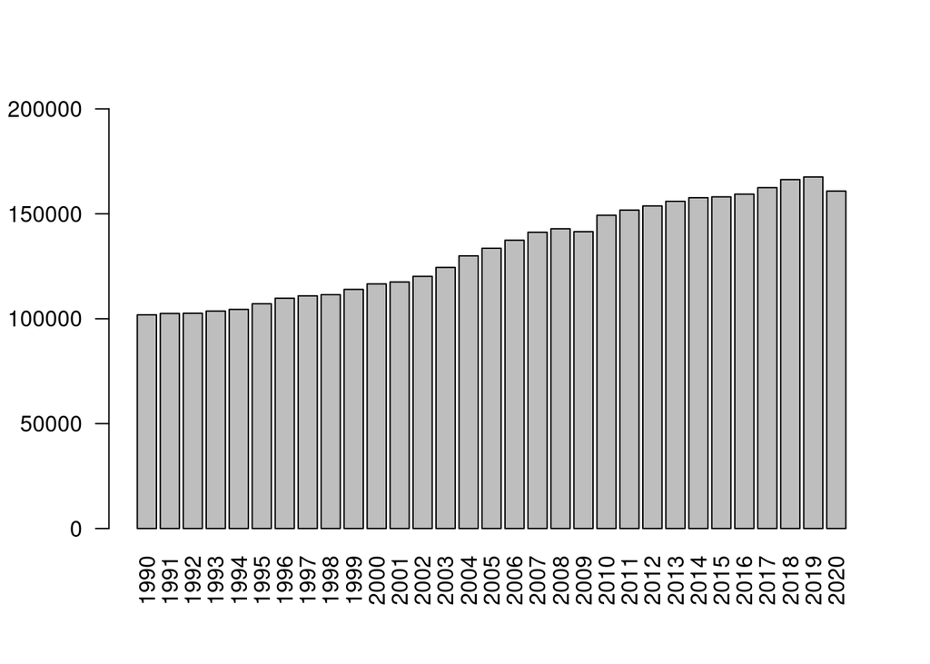

```r
barplot(energy$World, ylim = c(0, 200000),
        names.arg = energy$Year,
        las = 2)
```

Desafio:

Haga un grafico de lineas con la misma informacion arriba. (Dica: utilice el ?plot para buscar ayjada para transformar el grafico en tipo “linea”).

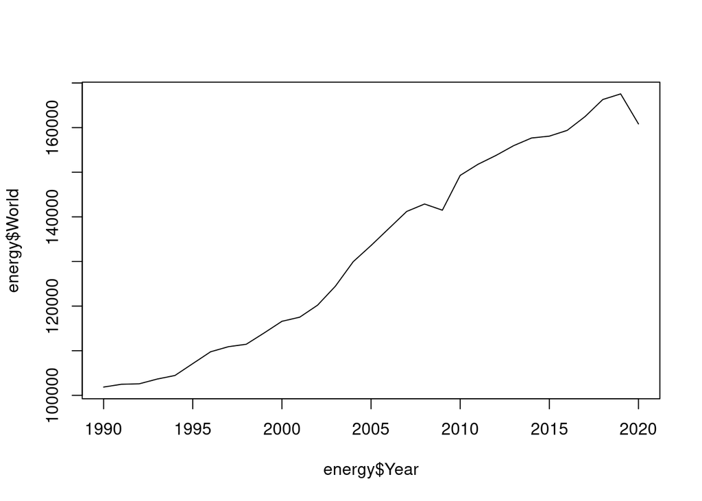

```r
plot(energy$Year, energy$World, type = "l")
```

2. América latina y altere los nombres del ejo x para Año y del ejo y para “Consumo de energía”

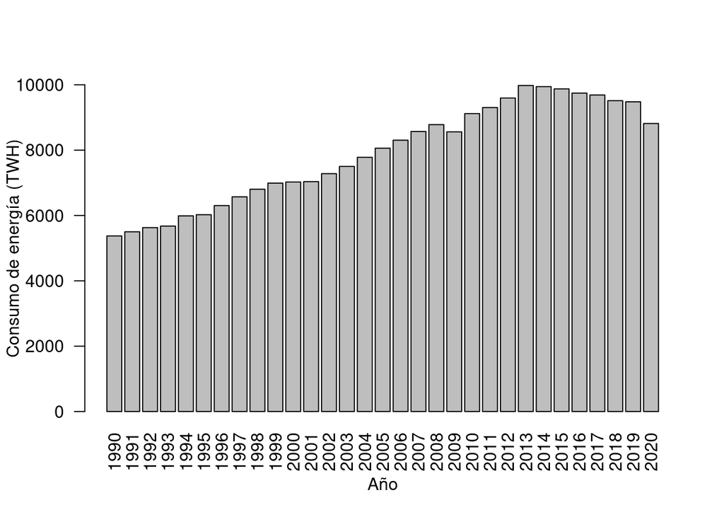

```r
barplot(energy$Latin.America, ylim = c(0, 10000),
        names.arg = energy$Year,
        las = 2,
        xlab = "Año",
        ylab = "Consumo de energía (TWH)")
```

3. Haga un heatmap con el consumo de energia en los paises en relacíon al consumo de los continentes (America Latina, America do Norte, Europa, CIS, …). Acuaerdate de hacer una matriz con los dados que se desea hacer el grafico (funcion as.matrix).

```r
energy_mat = as.matrix(energy[,3:ncol(energy)])
rownames(energy_mat) = energy$Year
```

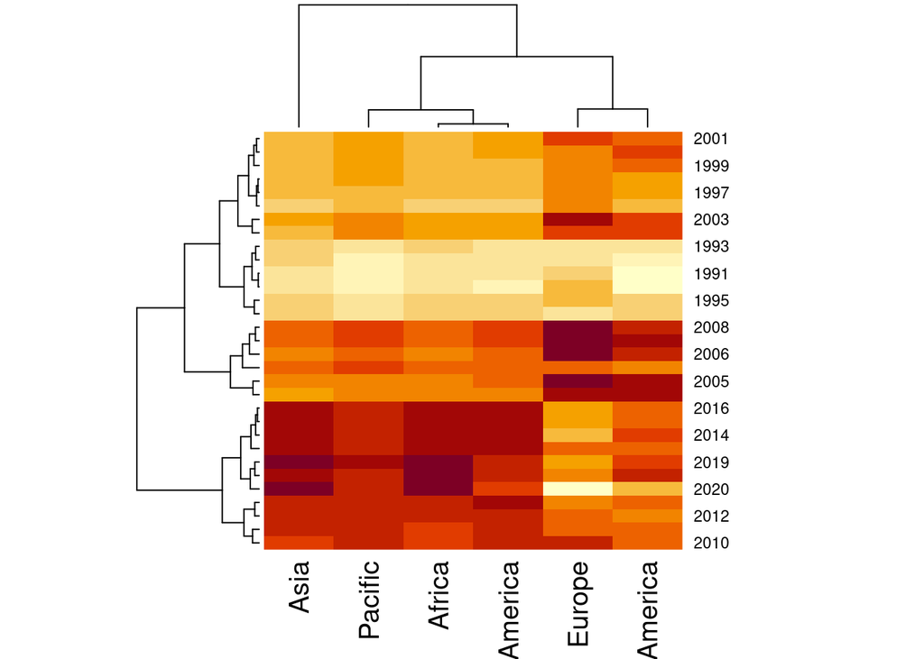

```r
heatmap(energy_mat, scale = "column")
```

Haga un grafico de puntos relacionando el consumo de energía en America latina y el consumo mundial.

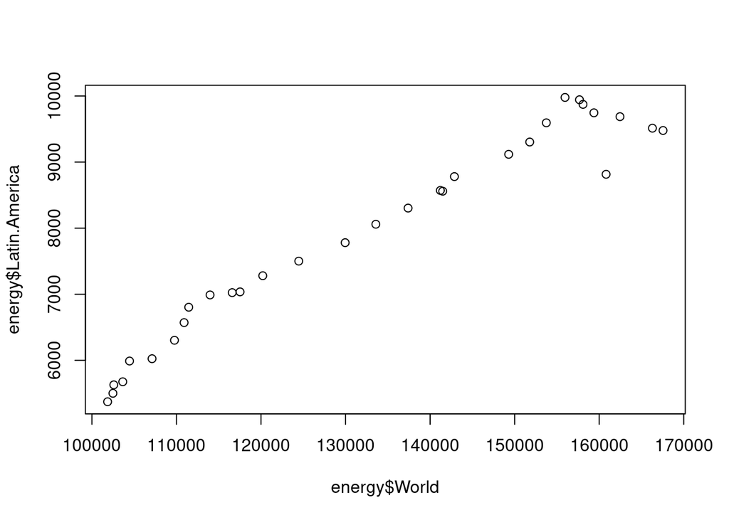

```r
plot(energy$World, energy$Latin.America)
```

Hace un grafico con el consumo de energia por región en 2020.

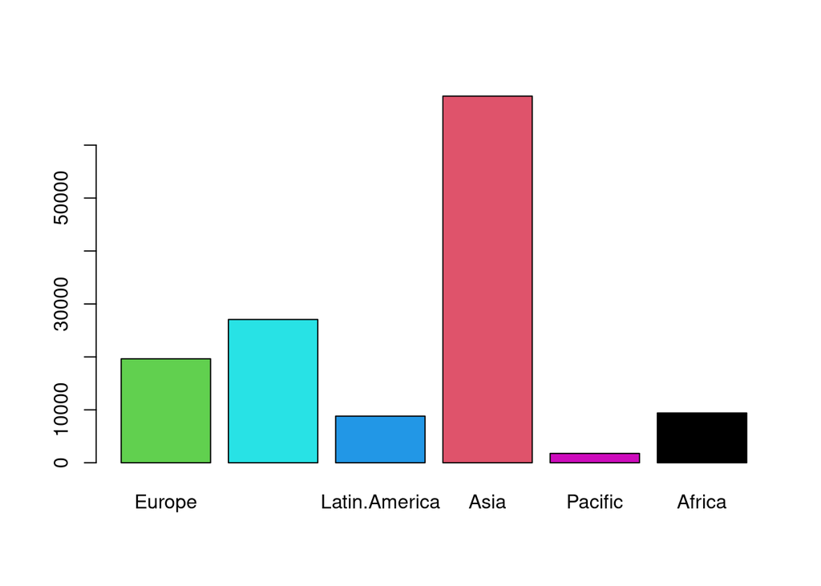

```r
energy_sub_year = energy_mat[31,]
barplot(energy_sub_year, col = factor(names(energy_sub_year)))
```

```r
energy2020 = energy[31,-c(1)]
energy2020 = t(energy2020)
colnames(energy2020) = "Energy Consumption in 2020"
head(energy2020)
```

```
##               Energy Consumption in 2020
## World                          160819.64
## Europe                          19643.07
## North.America                   27063.01
## Latin.America                    8815.54
## Asia                            69256.65
## Pacific                          1767.76
```

```r
energy2020 = as.data.frame(energy2020)
str(energy2020)
```

```
## 'data.frame':    7 obs. of  1 variable:
##  $ Energy Consumption in 2020: num  160820 19643 27063 8816 69257 ...
```

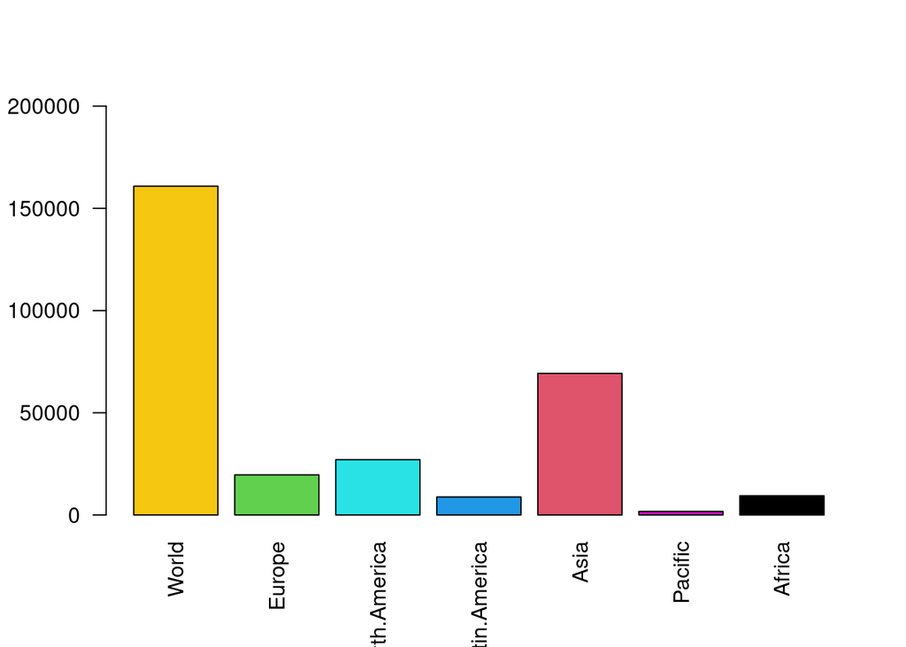

```r
barplot(energy2020$`Energy Consumption in 2020`, ylim = c(0,200000),
        names.arg = rownames(energy2020),
        las = 2,
        col = as.factor(rownames(energy2020)))
```